# Final Project

Jiayue He & Xuefei Wang

12-16-2019

# Introduction

YouTube is the most popular and most used video platform in the whole world today. Here we are going to get the trending statistics by analyzing the YouTube Trending datasets which are collected from three English-Speaking countries: the US, the UK and Canada. Our research question is to explore those trending videos among those three countries. Our goal is to find what kinds of videos are the most popular in different countries, what makes them popular, what are the similarities and difference between those videos and the how do the YouTube users would like to engage in which category(like, dislike and comment).

[figure not shown]

# Step 1: Load Packages

```r
rm(list = ls())
```

```r
library(mosaic)
library(DataComputing)
library(tidyverse)
library(mosaicData)
library(dplyr)
library("rjson")
library(ggplot2)
library(lubridate)
library(party)
```

# Step 2: Importing and Preparing data

```r
US <- read.csv("USvideos.csv")
Canada <- read.csv("CAvideos.csv")
GreatBritain <- read.csv("GB.csv")
```

```r
CategoryID <- fromJSON(file = "CA_category_id.json")
list <- CategoryID[["items"]]
items <- length(list)
ids <- numeric(items)
for(i in 1 : 31) {
  ids[i] <- CategoryID[["items"]][[i]][[3]]
}
names <- character(items)
for(i in 1 : 31) {
  names[i] <- CategoryID[["items"]][[i]][[4]][[2]]
}
names <- c('Film & Animation', 'Autos & Vehicles', 'Music', 'Pets & Animals',
           'Sports', 'Short Movies', 'Travel & Events', 'Gaming', 'Videoblogging',
           'People & Blogs', 'Comedy', 'Entertainment', 'News & Politics',
           'How to & Style', 'Education', 'Science & Technology',
           'Nonprofits & Activism', 'Movies', 'Anime/Animation', 'Action/Adventure',
           'Classics', 'Comedy2', 'Documentary', 'Drama', 'Family', 'Foreign',
           'Horror', 'Sci-Fi/Fantasy', 'Thriller', 'Shorts', 'Shows')
Canada$categories <- factor(Canada$category_id, levels = ids, labels = names)
US$categories <- factor(US$category_id, levels = ids, labels = names)
GreatBritain$categories <- factor(GreatBritain$category_id, levels = ids, labels = names)
```

In step 2, we upload our data source which include three CSV files and one JSON file. One of the variables in CAV files are presented in number, therefore, we match the corresponding information from JSON to the data frame we create. In order to accomplish this goal, we write some lists and a for loop with help of TA.

# Step 3: Explore Data Tables by Using Summary Functions

```r
head(US)
```

|  | video_id | trending_date | title | channel_title | category_id | publish_time | tags | views | likes | dislikes | comment_count | thumbnail_link | comments_disabled | ratings_disabled | video_error_or_removed | description | categories |
| --- | --- | --- | --- | --- | --- | --- | --- | --- | --- | --- | --- | --- | --- | --- | --- | --- | --- |
| 1 | 1ZAPwfrtAFY | 17.13.11 | The Trump Presidency: Last Week Tonight with John Oliver (HBO) | LastWeekTonight | 24 | 2017-11-13T07:30:00.000Z | last week tonight trump presidency\|last week tonight donald trump\|john oliver trump\|donald trump | 993345 | 65551 | 3544 | 8128 | https://i.ytimg.com/vi/1ZAPwfrtAFY/default.jpg | False | False | False | One year after the presidential election, John Oliver discusses what we've learned so far and enlists our catheter cowboy to teach Donald Trump what he hasn't.\\n\\nConnect with Last Week Tonight onli… | Entertainment |
| 2 | 5qpjK5DgCt4 | 17.13.11 | Racist Superman \| Rudy Mancuso, King Bach & Lele Pons | Rudy Mancuso | 23 | 2017-11-12T19:05:24.000Z | racist superman\|rudy\|mancuso\|king\|bach\|racist\|superman\|love\|rudy mancuso poo bear black white official music video\|iphone x by pineapple\|lelepons\|hannahstocking\|rudymancuso\|inanna\|anwar\… | 2568721 | 132724 | 4495 | 7494 | https://i.ytimg.com/vi/5qpjK5DgCt4/default.jpg | False | False | False | WATCH MY PREVIOUS VIDEO ▶ \\n\\nSUBSCRIBE ► https://www.youtube.com/channel/UC5jkXpfnBhlDjqh0ir5FsIQ?sub_confirmation=1\\n\\nTHANKS FOR WATCHING! LIKE & SUBSCRIBE FOR MORE VIDEOS!\\n------------------… | Comedy |
| 3 | puqaWrEC7tY | 17.13.11 | Nickleback Lyrics: Real or Fake? | Good Mythical Morning | 24 | 2017-11-13T11:00:04.000Z | rhett and link\|gmm\|good mythical morning\|rhett and link good mythical morning\|good mythical morning rhett and link\|mythical morning\|Season 12\|nickelback lyrics\|nickelback lyrics real or fake\|… | 118585 | 6183 | 361 | 1374 | https://i.ytimg.com/vi/puqaWrEC7tY/default.jpg | False | False | False | Today we find out if Link is a Nickelback amateur or a secret Nickelback devotee. GMM #1218\\nDon't miss an all new Ear Biscuits: https://goo.gl/xeZNQt\\nWatch Part 4: https://youtu.be/MhCdiiB8CQg \| … | Entertainment |
| 4 | d380meD0W0M | 17.13.11 | I Dare You: GOING BALD!? | nigahiga | 24 | 2017-11-12T18:01:41.000Z | ryan\|higa\|higatv\|nigahiga\|i dare you\|idy\|rhpc\|dares\|no truth\|comments\|comedy\|funny\|stupid\|fail | 1867990 | 123933 | 1836 | 16635 | https://i.ytimg.com/vi/d380meD0W0M/default.jpg | False | False | False | I know it's been a while since we did this show, but we're back with what might be the best episode yet!\\nLeave your dares in the comment section! \\n\\nOrder my book how to write good \\nhttp://higa… | Entertainment |
| 5 | nc99ccSXST0 | 17.13.11 | 5 Ice Cream Gadgets put to the Test | CrazyRussianHacker | 28 | 2017-11-12T21:50:37.000Z | 5 Ice Cream Gadgets\|Ice Cream\|Cream Sandwich Maker\|gadgets\|gadget review\|review\|unboxing\|kitchen gadgets\|Gadgets put to the Test\|testing\|10 Kitchen Gadgets\|7 Camping Coffee Gadgets\|10 Kitc… | 669608 | 21357 | 591 | 3050 | https://i.ytimg.com/vi/nc99ccSXST0/default.jpg | False | False | False | Ice Cream Pint Combination Lock - http://amzn.to/2ACipdI\\nMini Ice Cream Sandwich Maker - http://amzn.to/2ACiX3g\\nMotorized Ice Cream Cone - http://amzn.to/2jkrYdg\\nBall Ice Cream Maker - http://am… | Science & Technology |
| 6 | 39idVpFF7NQ | 17.13.11 | Roy Moore & Jeff Sessions Cold Open - SNL | Saturday Night Live | 24 | 2017-11-12T05:37:17.000Z | SNL\|Saturday Night Live\|SNL Season 43\|Episode 1730\|Tiffany Haddish\|Roy Moore\|Mikey Day\|Mike Pence\|Beck Bennett\|Jeff Sessions\|Kate McKinnon\|s43\|s43e5\|episode 5\|live\|new york\|comedy\|ske… | 1926875 | 15159 | 2288 | 1837 | https://i.ytimg.com/vi/39idVpFF7NQ/default.jpg | False | False | False | Embattled Alabama Senate candidate Roy Moore (Mikey Day) meets with Vice President Mike Pence (Beck Bennett) and Attorney General Jeff Sessions (Kate McKinnon).\\n\\n#SNL #SNL43\\n\\nGet more SNL: htt… | Entertainment |

```r
tail(Canada)
```

|  | video_id | trending_date | title | channel_title | category_id | publish_time | tags | views | likes | dislikes | comment_count | thumbnail_link | comments_disabled | ratings_disabled | video_error_or_removed | description | categories |
| --- | --- | --- | --- | --- | --- | --- | --- | --- | --- | --- | --- | --- | --- | --- | --- | --- | --- |
| 194 | f-UzOpuKOVY | 17.13.11 | Fukrey Returns \| Trailer \| Pulkit Samrat \| Varun Sharma \| Manjot Singh \| Ali Fazal \| Richa Chadha | excelmovies | 24 | 2017-11-13T04:56:26.000Z | Fukrey\|"Fukrey Returns"\|"Comedy"\|"Padmavati"\|"Pulkit Samrat"\|"Varun sharma"\|"Manjot Singh"\|"Ali Fazal"\|"Richa Chadha"\|"Farhan Akhtar"\|"Ritesh Sidhwani"\|"Tiger Zinda Hai"\|"Bollywood"\|"Hind… | 2531920 | 36299 | 905 | 1522 | https://i.ytimg.com/vi/f-UzOpuKOVY/default.jpg | FALSE | FALSE | FALSE | Fukron ki toli aa gayi hai waapis aur ab hai payback ki baari,\\nBholi Punjaban ka badla padega in Fukron pe bhaari \\nKya Choocha kar paayega complete apni prem kahaani? \\nKya Hunny decode kar paaye… | Entertainment |
| 195 | IF4Cbb_82l0 | 17.13.11 | Воскресный вечер с Владимиром Соловьевым от 12.11.2017 | Россия 24 | 24 | 2017-11-12T22:21:28.000Z | поединок\|"михеев"\|"полный контакт"\|"вечер с владимиром соловьевым"\|"ковтун"\|"жириновский"\|"сатановский"\|"соловьев"\|"вечер"\|"владимир соловьев" | 285914 | 1832 | 2350 | 1120 | https://i.ytimg.com/vi/IF4Cbb_82l0/default.jpg | FALSE | FALSE | FALSE | Воскресный вечер с Владимиром Соловьевым от 12.11.2017\n\\nПодпишитесь на канал: https://www.youtube.com/c/poedinoktv?sub_confirmation=1\n\\n\n\\nОфициальный канал ток-шоу на общественно-политические … | Entertainment |
| 196 | heL0ozxcN7o | 17.13.11 | 24 Oras November 12 2017 | 24 Oras News Today | 22 | 2017-11-11T16:30:00.000Z | 24 Oras November 12 2017\|"24 Oras"\|"24 Oras News Today"\|"24 Oras November 12" | 247808 | 566 | 161 | 178 | https://i.ytimg.com/vi/heL0ozxcN7o/default.jpg | FALSE | FALSE | FALSE | 24 Oras November 12 2017. | People & Blogs |
| 197 | 2XVtrBvxoNQ | 17.13.11 | 11.11 - The Storm Will Unfold/FakeNews Alert/No Space Corp/Another Dead Dr | Destroying The Illusion | 22 | 2017-11-11T23:47:15.000Z | jordan sather\|"destroying the illusion"\|"4chan"\|"donald trump"\|"putin"\|"russia"\|"clinton"\|"podesta"\|"deep state"\|"conspiracy"\|"las vegas"\|"false flag"\|"consciousness"\|"secret space progra… | 98990 | 3672 | 128 | 1088 | https://i.ytimg.com/vi/2XVtrBvxoNQ/default.jpg | FALSE | FALSE | FALSE | Orlando Airport Evacuation - https://goo.gl/qkwKjR\\nAir Traffic Controller Arrests for WMD's - https://goo.gl/kqtnm4\\nWeird Plane in San Jose - https://goo.gl/uGEGMv\\nWeird Planes in Las Vegas - ht… | People & Blogs |
| 198 | XjgOSetqCwI | 17.13.11 | People We'd Hate to See Accused Next... \| Boys Only Club Ep. 35 | Boys Only Club | 24 | 2017-11-12T16:00:08.000Z | podcast\|"discussion"\|"steven suptic"\|"reina scully"\|"steve zaragoza"\|"sourcefed"\|"nerd"\|"reunion"\|"louis ck"\|"allegations"\|"reaction"\|"rooster teeth"\|"RT"\|"animation"\|"filmmaking"\|"movi… | 33025 | 2215 | 32 | 452 | https://i.ytimg.com/vi/XjgOSetqCwI/default.jpg | FALSE | FALSE | FALSE | @stevezaragoza \\nhttps://www.youtube.com/user/stevezaragoza/\\nTORTY CLOUD: https://youtu.be/U7k1QAOPiZw\\n\\n2017 Gray Boy Hats: http://bit.ly/BoysOnly \\n\\nSubscribe, boys: https://www.youtube.com… | Entertainment |
| 199 | 8e0jY6_j4_g | 17.13.11 | J killer Corazon Roto - Leo Fenix X ContinentalMusic | ContinentalMusicTV | 10 | 2017-11-12T16:51:47.000Z | champeta\|"ozuna"\|"yandel"\|"donomar"\|"wisin"\|"savage21"\|"oscarprince"\|"djprofeta"\|"musica"\|"pop"\|"popular"\|"shakira"\|"gentedezona"\|"luisfonsi"\|"marcanthony"\|"jennyferlopez" | 33272 | 643 | 11 | 104 | https://i.ytimg.com/vi/8e0jY6_j4_g/default.jpg | FALSE | FALSE | FALSE | J killer Corazon Roto - Leo Fenix (Audio) official©\\n\\nRecuerda suscribirte a mi unico canal oficial y a mis demás redes sociales: http://www.youtube.com/ContinentalMusicTv\\n\\nhttp://www.facebook.… | Music |

```r
names(GreatBritain)
```

```
 [1] "video_id"               "trending_date"          "title"                  "channel_title"
 [5] "category_id"            "publish_time"           "tags"                   "views"
 [9] "likes"                  "dislikes"               "comment_count"          "thumbnail_link"
[13] "comments_disabled"      "ratings_disabled"       "video_error_or_removed" "description"
[17] "X"                      "X.1"                    "X.2"                    "X.3"
[21] "X.4"                    "X.5"                    "X.6"                    "X.7"
[25] "X.8"                    "X.9"                    "X.10"                   "X.11"
[29] "X.12"                   "X.13"                   "X.14"                   "X.15"
[33] "X.16"                   "X.17"                   "X.18"                   "X.19"
[37] "X.20"                   "X.21"                   "X.22"                   "X.23"
[41] "X.24"                   "X.25"                   "categories"
```

# Step 4: Clean Tables

```r
US <-
  US %>%
  filter(categories != " ")
Canada <-
  Canada %>%
  filter(categories != " ")
GreatBritain <-
  GreatBritain %>%
  filter(categories != " ")
```

```r
US <-
  US %>%
  filter(grepl("^2017-11+", publish_time, ignore.case = TRUE))
Canada <-
  Canada %>%
  filter(grepl("^2017-11+", publish_time, ignore.case = TRUE))
GreatBritain <-
  GreatBritain %>%
  filter(grepl("^2017-11+", publish_time, ignore.case = TRUE))
```

```r
US <-
  US %>%
  mutate(publish_time = as.POSIXct(US$publish_time))
Canada <-
  Canada %>%
  mutate(publish_time = as.POSIXct(Canada$publish_time))
GreatBritain <-
  GreatBritain %>%
  mutate(publish_time = as.POSIXct(GreatBritain$publish_time))
```

After exploring these data from previous step, we filter out some errors in the data frames to make them tidy.

# Step 5: Data Wrangling

```r
US <-
  US %>%
  select(title, publish_time, channel_title, categories, publish_time, tags,
         views, likes, dislikes, comment_count, thumbnail_link, description)
Canada <-
  Canada %>%
  select(title, publish_time, channel_title, categories, publish_time, tags,
         views, likes, dislikes, comment_count, thumbnail_link, description)
GreatBritain <-
  GreatBritain %>%
  select(title, publish_time, channel_title, categories, publish_time, tags,
         views, likes, dislikes, comment_count, thumbnail_link, description)
```

```r
View(US)
View(Canada)
View(GreatBritain)
```

We selecte variables that we are interested in; we are going to analyze and find their features in the following steps.

# Step 6: Visualization

## US

```r
US1 <-
  US %>%
  mutate(view = views / 1000)
```

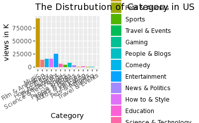

```r
US1 %>%
  ggplot(aes(x = reorder(categories, -view), y = view, fill = categories)) +
  geom_bar(stat = "identity") +
  theme(axis.text.x = element_text(angle = 30, hjust = 1)) +
  labs(y = "views in K", x = "Category", title = "The Distrubution of Category in US")
```

```r
US1 <-
  US1 %>%
  filter(categories != "Music") %>%
  filter(categories != "Entertainment")
```

After drawing this graph, we notice that “Music” is a really outstanding category. We decide to take it out of the list because most of people use YouTube to listen to music. In addition, we realize except for “Music”, “Entertainment” is too wide to be a variable in this list. “Entertainment” is not a specific type because it could represent other types in this list, such as “Comedy”. Therefore, we filter out “Entertainment” from categories.

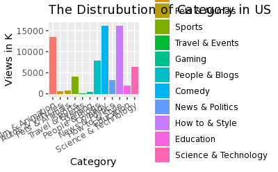

```r
US1 %>%
  ggplot() +
  geom_bar(aes(x = categories, y = view, fill = categories), stat = "identity") +
  theme(axis.text.x = element_text(angle = 30, hjust = 1)) +
  labs(y = "Views in K", x = "Category", title = "The Distrubution of Category in US")
```

In this graph, we discover there are three categories of videos have most views in the US. They are “How to & Style”, “Comedy”, “Film & Animation”. As the graph shows, there are also some categories have least views, which are “Travel & Events”, “Gaming”, “Autos & Vehicles”, “Pets & Animals”.

## Canada

```r
Canada1 <-
  Canada %>%
  filter(categories != "Music") %>%
  filter(categories != "Entertainment") %>%
  mutate(view = views / 1000)
```

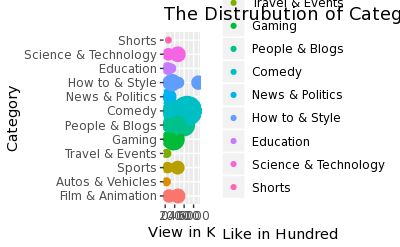

```r
Canada1 %>%
  mutate(like = likes / 100) %>%
  ggplot(aes(x = view, y = categories, color = categories, size = like)) +
  geom_point() +
  scale_size(range = c(1, 10), name = "Like in Hundred") +
  labs(x = "View in K", y = "Category", title = "The Distrubution of Category in Canada")
```

This graph indicates people in Canada enjoy “Comedy”, plus “People & Blogs” is also a popular category. There is an extreme outlier in “How to & Style”, which has the most views. Overall, “Comedy” and “How to & Style” have the most potential and steady videos which have more views and likes than other types’ videos. However, the category “Shorts” contains only one video which is pretty fun to explore.

## Great Britian

```r
GreatBritain1 <-
  GreatBritain %>%
  filter(categories != "Music") %>%
  filter(categories != "Entertainment") %>%
  arrange(desc(views)) %>%
  head(120)
```

We know that there are about 4000 cases in GreatBritain, and othere two are about 120 cases. It will be difficult for us to analyze with so many cases, so we decided to take some out. Since we filter out “Entertainment” and “Music” in previous data fram, there is no reason we keep these two categories in this data fram. We also arrange the order and pick the first 120 based on most views.

```r
GreatBritain1 <-
  GreatBritain1 %>%
  mutate(view = views / 1000)
```

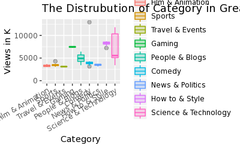

```r
GreatBritain1 %>%
  ggplot(aes(y = view, x = categories)) +
  geom_boxplot(aes(color = categories, fill = categories), alpha = 0.25,
               outlier.size = 2, outlier.colour = "black") +
  ylim(0, 13000) +
  labs(x = "Category", y = "Views in K",
       title = "The Distrubution of Category in Great Britain") +
  theme(axis.text.x = element_text(angle = 30, hjust = 1))
```

We graph a box plot to explore the relationship between “Category” and “Views” in GreatBretain. First, the category “Sicence & Technology” has the largest range and it is the most common tags that people watch. “Comedy” has an outlier which may get more than 12500k views even though the range of this category is pretty small. Compare to the US, “Film & Animation” is not really popular in the UK. Similarly, onece again “Travel & Envents” is the least popular type.

## All Three Countries

```r
All0 <-
  rbind(US1, Canada1, GreatBritain1)
View(All0)
```

In this part, we combine three data frames together from different countries.

```r
All0 <-
  All0 %>%
  filter(as.numeric(likes) > 100)
```

```r
avgAll <-
  All0 %>%
  group_by(categories, view, likes, dislikes, comment_count) %>%
  summarise(avgview = mean(view, na.rm = TRUE))
```

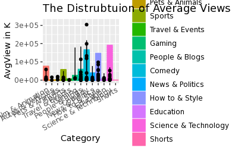

```r
avgAll %>%
  ggplot(aes(x = categories, y = avgview)) +
  geom_bar(aes(color = categories, fill = categories), stat = "identity") +
  geom_point(data = US1, aes(x = categories, y = likes)) +
  geom_line(data = Canada1, aes(x = categories, y = likes)) +
  ylim(0, 320000) +
  theme(axis.text.x = element_text(angle = 30, hjust = 1)) +
  labs(x = "Category", y = "AvgView in K", title = "The Distrubtuion of Average Views")
```

## Engagement

```r
All <-
  rbind(US, Canada, GreatBritain)
```

```r
engagement <-
  All %>%
  group_by(categories) %>%
  mutate(engage = as.numeric(likes) + as.numeric(dislikes) +
         as.numeric(comment_count)) %>%
  summarise(total = sum(engage, na.rm = TRUE)) %>%
  arrange(desc(total))
engagement
```

| categories | total |
| --- | --- |
| Music | 242461645 |
| Entertainment | 92409453 |
| Comedy | 21010501 |
| Science & Technology | 11069737 |
| How to & Style | 10555446 |
| People & Blogs | 9701584 |
| Film & Animation | 6003256 |
| Gaming | 4200263 |
| Sports | 2836331 |
| News & Politics | 2797266 |

[output cut: 5 more lines]

```r
percentage <-
  All %>%
  mutate(engage = as.numeric(likes) + as.numeric(dislikes) + as.numeric(comment_count),
         "dislikep" = ((as.numeric(dislikes) / engage) * 100),
         "likep" = ((as.numeric(likes) / engage) * 100),
         "commentp" = ((as.numeric(comment_count) / engage) * 100)) %>%
  select(publish_time, dislikep, likep, commentp) %>%
  arrange(desc(dislikep))
```

Here we combine all the data from three countries to analyze the calculate the percentage of “likes”, “dislikes” and “comment_count” in the whole engagement. By this way, we could know how the users would like to react to these videos by whic category: like, dislike or make a comment.

```r
plot<-
  percentage %>%
  gather(key = engagetype, value = per_engage, dislikep, likep, commentp)
```

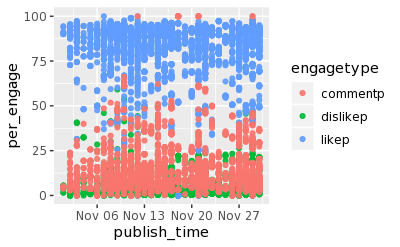

```r
plot %>%
  ggplot(aes(publish_time, per_engage, color = engagetype, fill = engagetype),stat = "identity") +
  geom_point(alpha = 0.9) +
  theme(legend.position = "right")
```

# Conclusion

Overall, we found that the popular videos differ in categories in different countries and there are lots of elements that will make these videos popular. Here we explore it by finding the relationship among these elements: categories of trending videos, types of engagement type(like,dislike and comment) and their total counts, YouTube users from three different countries and publish time of videos. First, we make different types of plots for each country to know the most trending category videos in different countries. For US, the most popular category videos are “Howto & Style” and “Comedy”. For UK, the most popular category videos is “Science & Technology”. For Canada, the most popular category videos are “Comedy” and “People & Blogs”. It is interesting because users from different countries like different kinds of videos. We may attributes this to different culture and religious. What’more, we could also indicates some typical characteristic of people in these three different countries. Another thing we’ve explored is to find which country of users make the most contributions to those trending videos for each category. For example, in the category of “Comedy”, the US and Canada has the largest average number for “views” which implies that users in the US and Canada contributes most to make “Comedy” the most popular catrgories. Finally, we explore how these users like to engage by like, dislike or making comments for these trending videos. The result shows users are more likely to “like” these popular videos which indicates that the count of “likes” will make a video more popular and trending.